# INTELLIGENT INVESTMENT CONSULTANT FOR LENDING CLUB</p>

### Author: Kun Jiang

### Email: kunjiang0112@gmail.com

# INTRODUCTION

[go back to the top]

[Lending Club](https://www.lendingclub.com/) is a US peer-to-peer lending company that provides a largest peer-to-peer online lending platform. The Lending Club’s platform enables borrowers to obtain a loan funded by investors. Investors profit from interest payments on loans. Based on the levels of loans' default rate, Lending categorizes the quality of the loans into seven grades, each of which assigned with different interest rates and risks. From the investors' point of view, they want to find out the potential default rate of each specific loans, in order to avoid investing on those loans with high risk of default. **The goal of this project is to build a predictive model to predict the default rate of the newly issued loans, based on information from historic loans.**

The centerpiece of this model’s operation is to use algorithm to choose which notes to invest in. Often investors have to choose between hundreds or thousands of available loans at Lending Club. This model makes the process easier by using machine-learning to calculate which notes are more likely to perform better than others. The moment new loans are added to the platforms, the algorithm analyzes the variables of these loans and only invests in the best ones.

# PROJECT SUMMARY

[go back to the top]

This project is implemented using Python on the Jupyter Notebook platform. Data processing and machine learning packages such as Pandas and Sci-kit Learn are utilized. The modeling is trained based on the Lending Club's historic loan data from year 2014.

The target is to predict the default rate of the new loans listed on Lending Club. The workflow of the project consists of 6 steps:

- Loading Data
- Exploratory Analysis
- Feature Engineering
- Model Building
- Model Integration
- Model Evaluation

Data cleaning are performed to uniform the features used in the training set and the target set. Categorical variables are extracted into meaningful features for model input via feature engineering. XGBoost (Extreme Gradient Boost) is used as the modeling algorithm. As an advanced Gradient Boosted Regression Trees (GBRT) algorithm, XGBoost adopted several advantages of GBRT such as: natural handling of data of mixed type , predictive power, robustness to outliers in output space (via robust loss functions). Combining both Random Forest and Adaptive Gradent Boosting algorithms, XGBoost exhibited high efficiency and flexibility in modeling large datasets with ease of implementation.

## Required Libraries

This notebook uses several standard Python packages and special packages for model building and model tuning. The primary libraries that we'll be using are:

- **requests**: request data from API servers.
- **pandas**: and **numpy**: numeric paneled data operation.
- **matplotlib** and **seaborn**: data visualization.
- **bayes_opt**: Bayesian Optimization.
- **sklearn**: Sci-kit Learn for model buidling and evaluation.
- **xgboost**: XGBoost algorithm.

```python
import requests
import json
import pandas as pd
import numpy as np
import matplotlib.pyplot as plt
import datetime as dt
import seaborn as sns
import xgboost as xgb
%matplotlib inline
```

# Data Acquisition

[go back to the top]

## Load Current Loan Data

Lending Club constantly updates its newly issued loans, which are accessed via Lending Club's API services. The data are loaded into Pandas DataFrame using Python's "requests" function. The current loan data are then saved into json format and read into Pandas DataFrame.

```python
api_key = open('apikeys.txt', 'r').read()
headers = {"Authorization": api_key}
url = 'https://api.lendingclub.com/api/investor/v1/loans/listing'
```

```python
r = requests.get(url, headers = headers)
```

```python
data = r.json()
```

```python
myData = data['loans']
```

```python
with open('current_list.txt', 'w') as outfile:
    json.dump(myData, outfile)
```

```python
df_current = pd.read_json('current_list.txt')
```

```python
df_current.head()
```

|  | accNowDelinq | accOpenPast24Mths | acceptD | addrState | addrZip | allUtil | annualInc | annualIncJoint | applicationType | avgCurBal | ... | totCollAmt | totCurBal | totHiCredLim | totalAcc | totalBalExMort | totalBalIl | totalBcLimit | totalCuTl | totalIlHighCreditLimit | totalRevHiLim |
| --- | --- | --- | --- | --- | --- | --- | --- | --- | --- | --- | --- | --- | --- | --- | --- | --- | --- | --- | --- | --- | --- |
| 0 | 0 | 2 | 2018-06-16T13:52:44.000-07:00 | NY | 145xx | 50.5 | 74000 | NaN | INDIVIDUAL | 13176 | ... | 0 | 197646 | 230283 | 34 | 32454 | 14995 | 18000 | 4 | 26270 | 38000 |
| 1 | 0 | 8 | 2018-06-16T16:51:35.000-07:00 | IL | 612xx | 1.0 | 90000 | NaN | INDIVIDUAL | 4307 | ... | 0 | 90437 | 186100 | 24 | 858 | 0 | 53700 | 3 | 0 | 87500 |

2 rows × 119 columns

```python
df_current.shape
```

```
(2, 119)
```

```python
print(df_current.columns.values)
```

```
['accNowDelinq' 'accOpenPast24Mths' 'acceptD' 'addrState' 'addrZip'
 'allUtil' 'annualInc' 'annualIncJoint' 'applicationType' 'avgCurBal'
 'bcOpenToBuy' 'bcUtil' 'chargeoffWithin12Mths' 'collections12MthsExMed'
 'creditPullD' 'delinq2Yrs' 'delinqAmnt' 'desc' 'disbursementMethod' 'dti'
 'dtiJoint' 'earliestCrLine' 'empLength' 'empTitle' 'expD' 'expDefaultRate'
 'ficoRangeHigh' 'ficoRangeLow' 'fundedAmount' 'grade' 'homeOwnership'
 'housingPayment' 'iLUtil' 'id' 'ilsExpD' 'initialListStatus' 'inqFi'
 'inqLast12m' 'inqLast6Mths' 'installment' 'intRate' 'investorCount'
 'isIncV' 'isIncVJoint' 'listD' 'loanAmount' 'maxBalBc' 'memberId'
 'moSinOldIlAcct' 'moSinOldRevTlOp' 'moSinRcntRevTlOp' 'moSinRcntTl'
 'mortAcc' 'mtgPayment' 'mthsSinceLastDelinq' 'mthsSinceLastMajorDerog'
 'mthsSinceLastRecord' 'mthsSinceRcntIl' 'mthsSinceRecentBc'
 'mthsSinceRecentBcDlq' 'mthsSinceRecentInq' 'mthsSinceRecentRevolDelinq'
 'numAcctsEver120Ppd' 'numActvBcTl' 'numActvRevTl' 'numBcSats' 'numBcTl'
 'numIlTl' 'numOpRevTl' 'numRevAccts' 'numRevTlBalGt0' 'numSats'
 'numTl120dpd2m' 'numTl30dpd' 'numTl90gDpd24m' 'numTlOpPast12m' 'openAcc'
 'openAcc6m' 'openActIl' 'openIl12m' 'openIl24m' 'openRv12m' 'openRv24m'
 'pctTlNvrDlq' 'percentBcGt75' 'pubRec' 'pubRecBankruptcies' 'purpose'
 'reviewStatus' 'reviewStatusD' 'revolBal' 'revolBalJoint' 'revolUtil'
 'secAppChargeoffWithin12Mths' 'secAppCollections12MthsExMed'
 'secAppEarliestCrLine' 'secAppFicoRangeHigh' 'secAppFicoRangeLow'
 'secAppInqLast6Mths' 'secAppMortAcc' 'secAppMthsSinceLastMajorDerog'
 'secAppNumRevAccts' 'secAppOpenAcc' 'secAppOpenActIl' 'secAppRevolUtil'
 'serviceFeeRate' 'subGrade' 'taxLiens' 'term' 'totCollAmt' 'totCurBal'
 'totHiCredLim' 'totalAcc' 'totalBalExMort' 'totalBalIl' 'totalBcLimit'
 'totalCuTl' 'totalIlHighCreditLimit' 'totalRevHiLim']
```

## Load 2014 Loan Data

Lending Club offers open access to its historical loan data from 2007. In this project the loan data from year 2014 were loaded into Pandas DataFrame to be used as the training set.

```python
df_2014 = pd.read_csv('data/LoanStats2014.csv', skiprows = 1, skipfooter=2)
```

```python
df_2014.head()
```

|  | id | member_id | loan_amnt | funded_amnt | funded_amnt_inv | term | int_rate | installment | grade | sub_grade | ... | sec_app_earliest_cr_line | sec_app_inq_last_6mths | sec_app_mort_acc | sec_app_open_acc | sec_app_revol_util | sec_app_open_il_6m | sec_app_num_rev_accts | sec_app_chargeoff_within_12_mths | sec_app_collections_12_mths_ex_med | sec_app_mths_since_last_major_derog |
| --- | --- | --- | --- | --- | --- | --- | --- | --- | --- | --- | --- | --- | --- | --- | --- | --- | --- | --- | --- | --- | --- |
| 0 | 36805548 | NaN | 10400 | 10400 | 10400 | 36 months | 6.99% | 321.08 | A | A3 | ... | NaN | NaN | NaN | NaN | NaN | NaN | NaN | NaN | NaN | NaN |
| 1 | 38098114 | NaN | 15000 | 15000 | 15000 | 60 months | 12.39% | 336.64 | C | C1 | ... | NaN | NaN | NaN | NaN | NaN | NaN | NaN | NaN | NaN | NaN |
| 2 | 37822187 | NaN | 9600 | 9600 | 9600 | 36 months | 13.66% | 326.53 | C | C3 | ... | NaN | NaN | NaN | NaN | NaN | NaN | NaN | NaN | NaN | NaN |
| 3 | 37662224 | NaN | 7650 | 7650 | 7650 | 36 months | 13.66% | 260.20 | C | C3 | ... | NaN | NaN | NaN | NaN | NaN | NaN | NaN | NaN | NaN | NaN |
| 4 | 37612354 | NaN | 12800 | 12800 | 12800 | 60 months | 17.14% | 319.08 | D | D4 | ... | NaN | NaN | NaN | NaN | NaN | NaN | NaN | NaN | NaN | NaN |

5 rows × 128 columns

```python
df_2014.shape
```

```
(235629, 128)
```

```python
print(df_2014.columns.values)
```

```
['id' 'member_id' 'loan_amnt' 'funded_amnt' 'funded_amnt_inv' 'term'
 'int_rate' 'installment' 'grade' 'sub_grade' 'emp_title' 'emp_length'
 'home_ownership' 'annual_inc' 'verification_status' 'issue_d'
 'loan_status' 'pymnt_plan' 'url' 'desc' 'purpose' 'title' 'zip_code'
 'addr_state' 'dti' 'delinq_2yrs' 'earliest_cr_line' 'fico_range_low'
 'fico_range_high' 'inq_last_6mths' 'mths_since_last_delinq'
 'mths_since_last_record' 'open_acc' 'pub_rec' 'revol_bal' 'revol_util'
 'total_acc' 'initial_list_status' 'out_prncp' 'out_prncp_inv'
 'total_pymnt' 'total_pymnt_inv' 'total_rec_prncp' 'total_rec_int'
 'total_rec_late_fee' 'recoveries' 'collection_recovery_fee' 'last_pymnt_d'
 'last_pymnt_amnt' 'next_pymnt_d' 'last_credit_pull_d'
 'last_fico_range_high' 'last_fico_range_low' 'collections_12_mths_ex_med'
 'mths_since_last_major_derog' 'policy_code' 'application_type'
 'annual_inc_joint' 'dti_joint' 'verification_status_joint'
 'acc_now_delinq' 'tot_coll_amt' 'tot_cur_bal' 'open_acc_6m' 'open_il_6m'
 'open_il_12m' 'open_il_24m' 'mths_since_rcnt_il' 'total_bal_il' 'il_util'
 'open_rv_12m' 'open_rv_24m' 'max_bal_bc' 'all_util' 'total_rev_hi_lim'
 'inq_fi' 'total_cu_tl' 'inq_last_12m' 'acc_open_past_24mths' 'avg_cur_bal'
 'bc_open_to_buy' 'bc_util' 'chargeoff_within_12_mths' 'delinq_amnt'
 'mo_sin_old_il_acct' 'mo_sin_old_rev_tl_op' 'mo_sin_rcnt_rev_tl_op'
 'mo_sin_rcnt_tl' 'mort_acc' 'mths_since_recent_bc'
 'mths_since_recent_bc_dlq' 'mths_since_recent_inq'
 'mths_since_recent_revol_delinq' 'num_accts_ever_120_pd' 'num_actv_bc_tl'
 'num_actv_rev_tl' 'num_bc_sats' 'num_bc_tl' 'num_il_tl' 'num_op_rev_tl'
 'num_rev_accts' 'num_rev_tl_bal_gt_0' 'num_sats' 'num_tl_120dpd_2m'
 'num_tl_30dpd' 'num_tl_90g_dpd_24m' 'num_tl_op_past_12m' 'pct_tl_nvr_dlq'
 'percent_bc_gt_75' 'pub_rec_bankruptcies' 'tax_liens' 'tot_hi_cred_lim'
 'total_bal_ex_mort' 'total_bc_limit' 'total_il_high_credit_limit'
 'revol_bal_joint' 'sec_app_fico_range_low' 'sec_app_fico_range_high'
 'sec_app_earliest_cr_line' 'sec_app_inq_last_6mths' 'sec_app_mort_acc'
 'sec_app_open_acc' 'sec_app_revol_util' 'sec_app_open_il_6m'
 'sec_app_num_rev_accts' 'sec_app_chargeoff_within_12_mths'
 'sec_app_collections_12_mths_ex_med' 'sec_app_mths_since_last_major_derog']
```

# Exploratory Analysis

[go back to the top]

Exploratory Analysis consist of parts:

- Feature Exploration
- Data Exploration
- Exploratory Visualization

```python
df_current.isnull().sum()
```

```
accNowDelinq                     0
accOpenPast24Mths                0
acceptD                          0
addrState                        0
addrZip                          0
allUtil                          0
annualInc                        0
annualIncJoint                   2
applicationType                  0
avgCurBal                        0
bcOpenToBuy                      0
bcUtil                           0
chargeoffWithin12Mths            0
collections12MthsExMed           0
creditPullD                      0
delinq2Yrs                       0
delinqAmnt                       0
desc                             2
disbursementMethod               0
dti                              0
dtiJoint                         2
earliestCrLine                   0
empLength                        0
empTitle                         0
expD                             0
expDefaultRate                   0
ficoRangeHigh                    0
ficoRangeLow                     0
fundedAmount                     0
grade                            0
                                ..
reviewStatusD                    0
revolBal                         0
revolBalJoint                    2
revolUtil                        0
secAppChargeoffWithin12Mths      2
secAppCollections12MthsExMed     2
secAppEarliestCrLine             2
secAppFicoRangeHigh              2
secAppFicoRangeLow               2
secAppInqLast6Mths               2
secAppMortAcc                    2
secAppMthsSinceLastMajorDerog    2
secAppNumRevAccts                2
secAppOpenAcc                    2
secAppOpenActIl                  2
secAppRevolUtil                  2
serviceFeeRate                   0
subGrade                         0
taxLiens                         0
term                             0
totCollAmt                       0
totCurBal                        0
totHiCredLim                     0
totalAcc                         0
totalBalExMort                   0
totalBalIl                       0
totalBcLimit                     0
totalCuTl                        0
totalIlHighCreditLimit           0
totalRevHiLim                    0
Length: 119, dtype: int64
```

```python
df_2014.isnull().sum()
```

```
id                                          0
member_id                              235629
loan_amnt                                   0
funded_amnt                                 0
funded_amnt_inv                             0
term                                        0
int_rate                                    0
installment                                 0
grade                                       0
sub_grade                                   0
emp_title                               13236
emp_length                              12019
home_ownership                              0
annual_inc                                  0
verification_status                         0
issue_d                                     0
loan_status                                 0
pymnt_plan                                  0
url                                         0
desc                                   220350
purpose                                     0
title                                       0
zip_code                                    0
addr_state                                  0
dti                                         0
delinq_2yrs                                 0
earliest_cr_line                            0
fico_range_low                              0
fico_range_high                             0
inq_last_6mths                              0
                                        ...
num_il_tl                                   0
num_op_rev_tl                               0
num_rev_accts                               0
num_rev_tl_bal_gt_0                         0
num_sats                                    0
num_tl_120dpd_2m                         7860
num_tl_30dpd                                0
num_tl_90g_dpd_24m                          0
num_tl_op_past_12m                          0
pct_tl_nvr_dlq                              0
percent_bc_gt_75                         2557
pub_rec_bankruptcies                        0
tax_liens                                   0
tot_hi_cred_lim                             0
total_bal_ex_mort                           0
total_bc_limit                              0
total_il_high_credit_limit                  0
revol_bal_joint                        235629
sec_app_fico_range_low                 235629
sec_app_fico_range_high                235629
sec_app_earliest_cr_line               235629
sec_app_inq_last_6mths                 235629
sec_app_mort_acc                       235629
sec_app_open_acc                       235629
sec_app_revol_util                     235629
sec_app_open_il_6m                     235629
sec_app_num_rev_accts                  235629
sec_app_chargeoff_within_12_mths       235629
sec_app_collections_12_mths_ex_med     235629
sec_app_mths_since_last_major_derog    235629
Length: 128, dtype: int64
```

```python
missing_df = df_2014.isnull().sum().reset_index()
missing_df.columns = ['feature_name', 'missing_count']
missing_df = missing_df.loc[missing_df['missing_count']>0]
missing_df = missing_df.sort_values(by='missing_count')
```

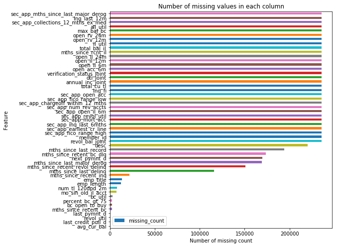

```python
missing_df.plot(x='feature_name', y='missing_count', kind='barh', figsize=(8,8),fontsize = 10, logx=False )
plt.title("Number of missing values in each column", fontsize = 12)
plt.xlabel("Number of missing count",fontsize=10)
plt.ylabel("Feature",fontsize=10)
plt.show()
```

```python
df_2014= df_2014.dropna(axis =1, how = 'all')
```

```python
df_2014.shape, df_current.shape
```

```
((235629, 97), (2, 119))
```

The target feature of the predictive model is labeled as "loan status", which refers to the stutus of loans as of today. A histogram is plotted to visualize the counts of different statuses. There are totally 7 different loan statuses, among which "Fully Paid" and "Charged Off" refer to those loans whose statuses are already determined, while all other statuses may still change over time. In this project only the loans with statuses of "Fully Paid" and "Charged Off" are considered. They are labeled as "0" (no default) and "1" (default), respectively.

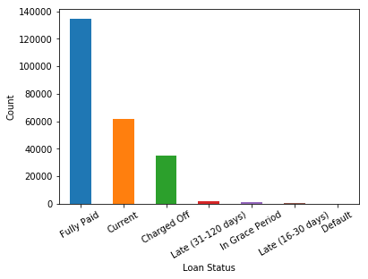

```python
fig = df_2014.loan_status.value_counts().plot('bar', rot = 90)
fig.set_xlabel('Loan Status')
fig.set_ylabel('Count')
plt.xticks(rotation = 30)
```

From the above histogram, it is seen that the ratio between "Fully Paid" and "Charged Off" loans are about 4:1. Discarding all other loan statuses, the overall default rate for the 2014 loans is about 0.2. Over time, this ratio may change slightly but this does not influence the training results much.

The term of the loans has only two values, 36 months or 60 months, in the ratio of about 2:1. As of the date of this project, most of the 36 months loans should be closed but most 60 months loans are still open. So this model will have a better prediction performance on the 36 months loans than the 60 months loans.

```
Text(0,0.5,'Count')
```

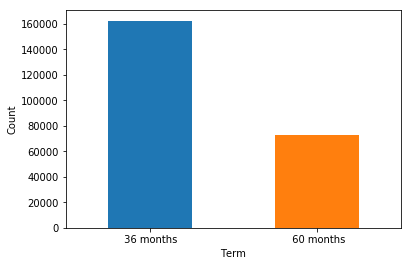

```python
fig = df_2014.term.value_counts().plot('bar', rot = 0)
fig.set_xlabel('Term')
fig.set_ylabel('Count')
```

## Feature Exploration

```python
df_2014.shape, df_current.shape
```

```
((235629, 97), (2, 119))
```

Features names have been formatted using the same rule before usage

```python
cols = []
for col in df_2014.columns:
    cols.append(col.replace("_", ""))
```

```python
df_2014.columns = cols
```

```python
cols = []
for col in df_current.columns:
    cols.append(col.lower())
```

```python
df_current.columns = cols
```

```python
# Change some column names in df_2014 to match df_current
# Fundedamnt to fundedamount. But this feature is not used since all loans in history data are fully funded.
df_2014.rename(columns={'zipcode': 'addrzip', 'verificationstatus': 'isincv', 'verificationstatusjoint': 'isincvjoint',\
                        'loanamnt': 'loanamount', 'numacctsever120pd': 'numacctsever120ppd'}, inplace=True)
```

Having uniformed the feature names, the next task is to find the common features in both historic and current data sets. The common features are extracted using set operations. The historic data frame df_2014 is then reduced to only have the common features plus the loan status ("loanstatus") and issued date ("issued").

```python
#Find common columns
com_cols = set(df_2014.columns) & set(df_current.columns)
hist_unique = set(df_2014.columns) - set (df_current.columns)
cur_unique = set(df_current.columns) - set (df_2014.columns)
```

```python
print(len(com_cols))
print(com_cols)
```

```
74
{'applicationtype', 'numtloppast12m', 'mosinoldrevtlop', 'numiltl', 'bcopentobuy', 'desc', 'ficorangelow', 'avgcurbal', 'id', 'mosinrcntrevtlop', 'numtl90gdpd24m', 'loanamount', 'pubrec', 'totcollamt', 'earliestcrline', 'numbctl', 'numrevaccts', 'totcurbal', 'mthssincelastrecord', 'mthssincerecentbc…
```

```python
print(len(hist_unique))
print(hist_unique)
```

```
23
{'recoveries', 'totalpymntinv', 'pymntplan', 'lastficorangehigh', 'outprncp', 'loanstatus', 'outprncpinv', 'lastpymntamnt', 'totalpymnt', 'fundedamntinv', 'lastcreditpulld', 'title', 'lastpymntd', 'collectionrecoveryfee', 'url', 'nextpymntd', 'totalrecprncp', 'issued', 'totalrecint', 'fundedamnt', '…
```

```python
print(len(cur_unique))
print(cur_unique)
```

```
45
{'annualincjoint', 'investorcount', 'secappmthssincelastmajorderog', 'secappcollections12mthsexmed', 'dtijoint', 'housingpayment', 'secappficorangelow', 'openacc6m', 'memberid', 'expd', 'maxbalbc', 'totalcutl', 'secappopenactil', 'expdefaultrate', 'inqfi', 'openrv12m', 'reviewstatus', 'secappnumreva…
```

```python
df_2014 = df_2014[list(com_cols) + ["loanstatus", "issued"]]
```

## Data Exploration

The next step is the preliminary data exploration. There are many all-null columns, which are dropped from the training set. The rows with loan statuses other than "Charged Off" or "Fully Paid" are also dropped from the training set. The resulted data frame has three different data types: "object", "int64", and "float64". All the "object" features are saved into a list of categorical variables "cat_vars', and all the numeric features are saved into "num_vars".

['intrate', 'addrzip', 'emplength', 'initialliststatus', 'emptitle', 'earliestcrline', 'grade', 'isincv', 'revolutil', 'homeownership', 'term', 'subgrade', 'purpose', 'addrstate', 'applicationtype', 'loanstatus', 'issued']

Each of them will be converted or transformed in the Feature Engineering step to be processed by the model algorithm.

```python
df_2014 = df_2014[df_2014.loanstatus.isin(["Charged Off", "Fully Paid"])]
```

```python
df_2014_raw = df_2014
```

```python
df_2014.shape
```

```
(169475, 76)
```

```python
data_types = df_2014.dtypes
cat_vars = list(data_types[data_types=='object'].index)
num_vars = list(data_types[data_types=='int64'].index) + list(data_types[data_types=='float64'].index)
```

```python
print ("There are %d categorical features. We will process them one by one." %len(cat_vars))
```

```
There are 18 categorical features. We will process them one by one.
```

```python
print(cat_vars)
```

```
['applicationtype', 'desc', 'earliestcrline', 'revolutil', 'initialliststatus', 'purpose', 'isincv', 'emptitle', 'term', 'addrstate', 'homeownership', 'subgrade', 'emplength', 'grade', 'intrate', 'addrzip', 'loanstatus', 'issued']
```

```python
print ("There are %d numerical features" %len(num_vars))
```

```
There are 58 numerical features
```

```python
print(num_vars)
```

```
['numtloppast12m', 'mosinoldrevtlop', 'numiltl', 'ficorangelow', 'id', 'mosinrcntrevtlop', 'numtl90gdpd24m', 'loanamount', 'pubrec', 'totcollamt', 'numbctl', 'numrevaccts', 'totcurbal', 'totalrevhilim', 'totalacc', 'accnowdelinq', 'numbcsats', 'ficorangehigh', 'totalilhighcreditlimit', 'numoprevtl',…
```

## Exploratory Visualization

Visualization packages "Matplotlib" and "Seaborn" were used to plot the distribution of the categorical features.

```python
print(len(cat_vars), len(num_vars), df_2014.shape)
```

```
18 58 (169475, 76)
```

```python
cat_vars_plot = ['applicationtype', 'isincv', 'purpose', 'subgrade', 'initialliststatus', 'addrstate', 'grade', 'term',\
                'homeownership', 'emplength']
```

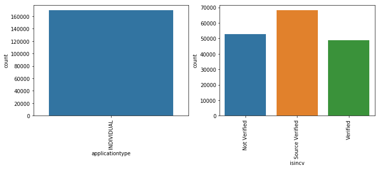

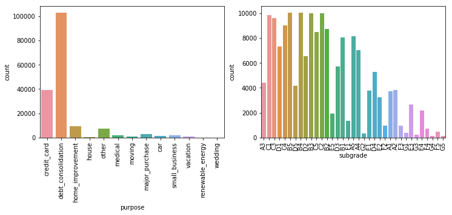

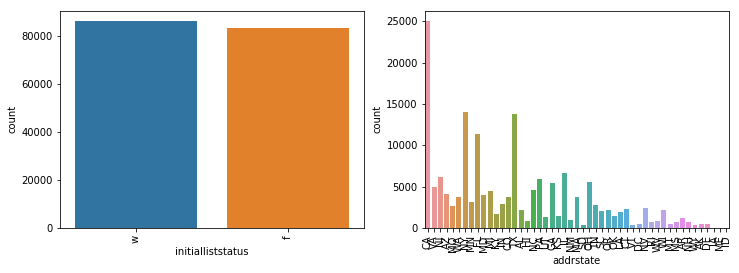

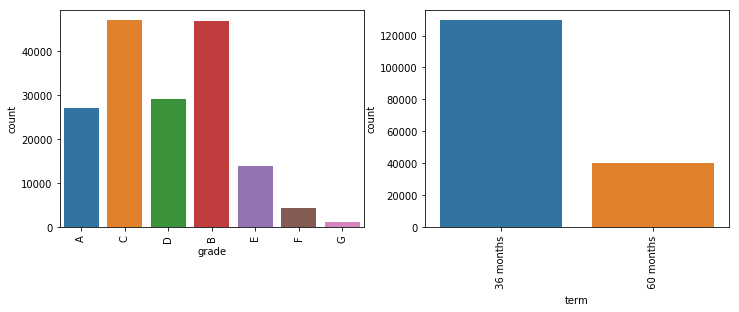

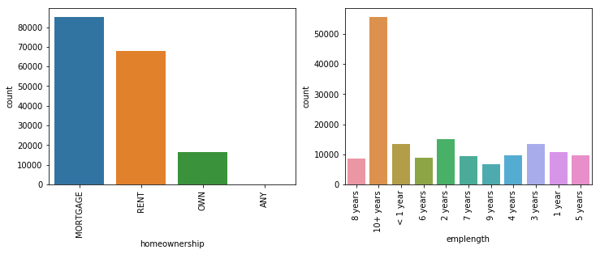

```python
n_cols = 2
n_rows = 5
for i in range(n_rows):
    fg,ax = plt.subplots(nrows=1,ncols=n_cols,figsize=(12, 4))
    for j in range(n_cols):
        g = sns.countplot(x=cat_vars_plot[i*n_cols+j], data=df_2014, ax=ax[j])
        g.set_xticklabels(labels=g.get_xticklabels(), rotation = 90)
```

# Feature Engineering

[go back to the top]

Feature engineering is conducted mainly on the categorical features. The purpose of feature engineering is either to convert categorical variables to numerical variables or extract new features that may potentially enhance model performance. There are 5 different types of categorical features, each is treated with different strategies. The table below lists each type of categorical features and their corresponding solutions.

| Type | Name | Definition | Solution |
| --- | --- | --- | --- |
| Intrinsically numerical | intrate | Interest rate | Convert to numerical |
|  | revolutil | Credit line utilization | .. |
|  | term | Term of loan (36/60) | .. |
| Date-time | earliestcrline | Date first credit line | Extract new feature: credit history |
| High cardinality | emptitle | Employment title | NLP and extract new features |
|  | desc | User comments | .. |
|  | addrzip | Zipcode | Encoding by frequency rate |
|  | addrstate | State | .. |
| Ordinal | grade | Loan risk grade | Label encoding |
|  | subgrade | Loan risk subgrade | .. |
|  | emplength | Months employed | .. |
| Other | applicationtype | Application type | Only one type. Drop the feature. |
|  | homeownership | Home ownership | One-hot encoding (OHE) |
|  | initialliststatus | Initial list status | .. |
|  | purpose | Purpose of loan | .. |
|  | Isincv | Is income verified? | .. |

## Categorical Feature Treatment

Categorical features are treated one-by-one based on the nature of each feature. After the treatment of each categorical feature, that feature name is removed from the categorical variables and a new feature is added into the numerical variables.

### Feature 1. "addrstate" - convert to frequency

The address state has over 48 unique values. It is hard to use dummy encoding for all of them. However, the frequency of each state may be associated with the default rate. So frequency encoding is performed on the address state feature.

```python
addrstate_freq = pd.DataFrame({'addrstate': df_2014.addrstate.value_counts(normalize = True).index, \
                               'state_freq': df_2014.addrstate.value_counts(normalize = True).values})
```

```python
df_2014 = pd.merge(df_2014, addrstate_freq, how = 'left', on = 'addrstate')
```

```python
cat_vars.remove('addrstate')
num_vars.append('state_freq')
```

```python
print(len(cat_vars), len(num_vars), df_2014.shape)
```

```
17 59 (169475, 77)
```

### Feature 2. 'addrzip' - convert to numeric zip and frequency.

In the raw data, the address zipcode is expressed in the format of "123XX", where the last two digits of the zipcode are masked. In this process, the first three digits of address zipcodes are extracted as numerical features by stripping "XX" from the entries. Then another feature "zip_freq" based on the frequency of zipcodes is also created.

```python
df_2014.addrzip = df_2014.addrzip.apply(lambda x: int(x.strip('xx')))

addrzip_freq = pd.DataFrame({'addrzip': df_2014.addrzip.value_counts(normalize = True).index, \
                             'zip_freq': df_2014.addrzip.value_counts(normalize = True).values})
```

```python
df_2014 = pd.merge(df_2014, addrzip_freq, how = 'left', on = 'addrzip')
```

```python
cat_vars.remove('addrzip')
num_vars.append('addrzip')
num_vars.append('zip_freq')
```

```python
print(len(cat_vars), len(num_vars), df_2014.shape)
```

```
16 61 (169475, 78)
```

### Feature 3. 'applicationtype' -remove from cat_vars

From the plot of this feature it is found that the only value of "application type" is "Individual". So this feature is dropped from the model.

```python
# Only one value in this feature. Remove.
cat_vars.remove('applicationtype')
```

```python
print(len(cat_vars), len(num_vars), df_2014.shape)
```

```
15 61 (169475, 78)
```

### Feature 4. 'desc' - combine levels. (nan - 0, short - 1, long - 2)

This is the description that users input when applying for loans. There is only a small portion of this feature that are non-empty. The entries for description are all different. A new feature "desc_islong" is thus extracted from this column, by treating the null values as 0, those with short descriptions as 1, and those with long descriptions as 2. Natural Language Processing is used in this case to differentiate the length of decriptions.

```python
df_2014.desc = df_2014.desc[df_2014.desc.notnull()].apply(lambda x: x.split('>')[1][:-3] if x.find('>') != -1 else x)
```

```python
desc_length = df_2014.desc[df_2014.desc.notnull()].apply(lambda x: len(x))
```

```python
median = desc_length.median()
```

```python
desc_islong = pd.DataFrame(desc_length.apply(lambda x: 1 if x < median else 2))
```

```python
desc_islong.columns = ['desc_islong']
```

```python
df_2014 = pd.merge(df_2014, desc_islong, how = 'left', left_index=True, right_index=True)
```

```python
df_2014.desc_islong = df_2014.desc_islong.fillna(0).astype('int')
```

```python
cat_vars.remove('desc')
num_vars.append('desc_islong')
```

```python
print(len(cat_vars), len(num_vars), df_2014.shape)
```

```
14 62 (169475, 79)
```

### Feature 5. 'earliestcrline' - create new feature as credit history length in days.

```python
earliest_crl = df_2014['earliestcrline'].apply(lambda x: dt.datetime.strptime(str(x), '%b-%Y'))
```

```python
# Credit history in days.
df_2014['credit_hist'] = earliest_crl.apply (lambda x: (dt.date(2018, 1, 1) - x.date()).days)
```

```python
cat_vars.remove('earliestcrline')
num_vars.append('credit_hist')
```

```python
print(len(cat_vars), len(num_vars), df_2014.shape)
```

```
13 63 (169475, 80)
```

### Feature 6. 'emplength' - convert to months

This feature is the length of employment. It contains ordinal levels of values from < 1 year to $\geqslant$10 years. The value of each level is extracted via Natural Language Processing and converted to months. Less than 1 year is labeled 0. For the n/a entries, it is likely that the user was unemployed, so any n/a values are replaced with a penalty term of "-999".

```python
df_2014.emplength.unique()
```

```
array(['8 years', '10+ years', '< 1 year', '6 years', '2 years', '7 years',
       '9 years', nan, '4 years', '3 years', '1 year', '5 years'], dtype=object)
```

```python
df_2014.emplength.replace('n/a', np.nan, inplace = True)
df_2014.emplength.replace('< 1 year', '0', inplace = True)
df_2014.emplength.replace(to_replace='[^0-9]+', value = '', inplace= True, regex= True)
```

```python
df_2014.emplength = df_2014.emplength[df_2014.emplength.notnull()].astype(int).apply(lambda x: x * 12)
```

```python
df_2014.emplength.fillna(-999, inplace = True)
```

```python
cat_vars.remove('emplength')
num_vars.append('emplength')
```

```python
print(len(cat_vars), len(num_vars), df_2014.shape)
```

```
12 64 (169475, 80)
```

The title of employment also vary significantly so it is impossible to use dummy encoding for this feature. It can be assumed that a person with a managerial title may have better credit. As a result, the entries in this column are analyzed to find words such as "manager", "president", and so on. Those with a managerial title are labeled 1, and those without are labeled 0. The users with an n/a entry in this column are likely unemployed, so a penalty term of "-999" is also used in place of "n/a".

```python
df_2014.emptitle = df_2014.emptitle.astype('str').apply(lambda x: x.lower())
```

```python
df_2014.replace('nan', np.nan, inplace = True)
```

```python
df_2014['emptype'] = np.nan
```

```python
ismanager = df_2014.emptitle.str.contains('manager|president|officer|supervisor|director|excutive')
```

```python
isnonmanager = (ismanager == False)
```

```python
ismanager.fillna(False, inplace= True)
```

```python
df_2014.emptype[ismanager] = 1
df_2014.emptype[isnonmanager] = 0
```

```python
df_2014.emptype.fillna(-999, inplace= True)
```

```python
cat_vars.remove('emptitle')
num_vars.append('emptype')
```

```python
print(len(cat_vars), len(num_vars), df_2014.shape)
```

```
11 65 (169475, 81)
```

### Feature 8. 'grade' - label encoding A-G -> 1-7

The "grade" feature is pre-categorized by Lending Club based on the risk levels of loans. It is simply label-coded here from A-G to 1-7.

```python
df_2014.grade = df_2014.grade.map({'A': 1, 'B': 2, 'C': 3, 'D': 4, 'E': 5, 'F': 6, 'G': 7})
```

```python
cat_vars.remove('grade')
num_vars.append('grade')
```

```python
print(len(cat_vars), len(num_vars), df_2014.shape)
```

```
10 66 (169475, 81)
```

### Feature 9. 'homeownership' - leave for one-hot encoding.

The home ownership feature has only three values: mortgage, rent, or own. One-hot Encoding is performed on this feature.

```python
df_2014.homeownership.replace('ANY', np.nan, inplace= True)
```

```python
homeownership_OHE = pd.get_dummies(df_2014['homeownership'])
```

```python
homeownership_OHE.columns = ['home_mort', 'home_own', 'home_rent']
```

```python
df_2014 = pd.merge(df_2014, homeownership_OHE, how= 'left', left_index = True, right_index= True)
```

```python
OHE_vars = []
OHE_vars = OHE_vars + list(homeownership_OHE.columns)
```

```python
cat_vars.remove('homeownership')
```

```python
print(len(cat_vars), len(num_vars), len(OHE_vars), df_2014.shape)
```

```
9 66 3 (169475, 84)
```

### Feature 10. 'initialliststatus' - map: W: 0, F: 1.

Only two values are in this feature: 0 or 1 for W or F.

```python
# Upper case to match the current loans data.
df_2014.initialliststatus = df_2014.initialliststatus.apply(lambda x: x.upper())
```

```python
df_2014.initialliststatus = df_2014.initialliststatus.map({'W': 0, 'F': 1})
```

```python
cat_vars.remove('initialliststatus')
num_vars.append('initialliststatus')
```

```python
print(len(cat_vars), len(num_vars), len(OHE_vars), df_2014.shape)
```

```
8 67 3 (169475, 84)
```

### Feature 11. 'intrate' - change to float

The feature of interest rate is intrinscally numerical. It is converted to a float number by removing the "%" sign.

```python
df_2014['intrate'] = df_2014.intrate.astype('str').transform(lambda x: float(x.strip('%'))/100)
```

```python
cat_vars.remove('intrate')
num_vars.append('intrate')
```

```python
print(len(cat_vars), len(num_vars), len(OHE_vars), df_2014.shape)
```

```
7 68 3 (169475, 84)
```

### Feature 12. 'isincv' - one hot encoding.

Only three different values are in this feature. It is noted that the historical entries may be in lower or upper cases but the entries in the current data have only upper cases. So they are uniformed to upper cases and One-hot Encoded.

```python
df_2014.isincv.replace(['Not Verified', 'Source Verified', 'Verified'], ['NOT_VERIFIED', 'SOURCE_VERIFIED', 'VERIFIED'],\
                          inplace= True)
```

```python
isincv_OHE = pd.get_dummies(df_2014['isincv'])
```

```python
isincv_OHE.columns = ['isincv_nv', 'isinicv_sv', 'isincv_v']
```

```python
df_2014 = pd.merge(df_2014, isincv_OHE, how='left', left_index = True, right_index= True)
```

```python
OHE_vars = OHE_vars + list(isincv_OHE.columns)
```

```python
cat_vars.remove('isincv')
```

```python
print(len(cat_vars), len(num_vars), len(OHE_vars), df_2014.shape)
```

```
6 68 6 (169475, 87)
```

### Feature 13. 'purpose' - one-hot encoding.

This feature describes the purpose of loan application. It is One-hot Encoded.

```python
purpose_OHE = pd.get_dummies(df_2014.purpose)
```

```python
purpose_OHE.columns = ['pur_' + var for var in purpose_OHE.columns.values]
```

```python
df_2014 = pd.merge (df_2014, purpose_OHE, how= 'left', left_index= True, right_index= True)
```

```python
OHE_vars =  OHE_vars + list(purpose_OHE.columns)
```

```python
cat_vars.remove('purpose')
```

```python
print(len(cat_vars), len(num_vars), len(OHE_vars), df_2014.shape)
```

```
5 68 19 (169475, 100)
```

### Feature 14. 'revolutil' - convert to float

This feature indicates the utilization rate of users' revolving credit limit. It is intrinsically numeric with removal of the "%" sign.

```python
df_2014.revolutil = df_2014.revolutil.astype('str').transform(lambda x: float(x.strip('%'))/100)
```

```python
cat_vars.remove('revolutil')
num_vars.append('revolutil')
```

```python
print(len(cat_vars), len(num_vars), len(OHE_vars), df_2014.shape)
```

```
4 69 19 (169475, 100)
```

### Feature 15. 'subgrade' - label encoding

Similar to the grade feature, this feature is ordinal and coded by label-coding.

```python
subgrd = df_2014.subgrade.sort_values().unique()
```

```python
df_2014.subgrade = df_2014.subgrade.map({subgrd[i]: i + 1 for i in range(len(subgrd))})
```

```python
cat_vars.remove('subgrade')
num_vars.append('subgrade')
```

```python
print(len(cat_vars), len(num_vars), len(OHE_vars), df_2014.shape)
```

```
3 70 19 (169475, 100)
```

### Feature 16. 'term' - remove 'months'

Only two types are in this feature, 36 months or 60 months. They are converted to numbers.

```python
df_2014.term = df_2014.term.apply(lambda x: ''.join(d for d in x if d.isdigit()))
```

```python
df_2014.term = df_2014.term.astype(int)
```

```python
cat_vars.remove('term')
num_vars.append('term')
```

```python
print(len(cat_vars), len(num_vars), len(OHE_vars), df_2014.shape)
```

```
2 71 19 (169475, 100)
```

```python
df_2014.applicationtype.unique()
```

```
array(['INDIVIDUAL'], dtype=object)
```

### Feature 17. 'issued' - convert to date - not in training set.

This feature only marks the issued date of each loan, which is useful for train-test splitting, but not used in the training model.

```python
df_2014.issued = df_2014.issued.astype('str').apply(lambda x: dt.datetime.strptime(str(x), '%b-%Y'))
```

```python
cat_vars.remove('issued')
```

### Feature 18. 'loanstatus' - Target - 'charged_off' = 1, 'fully_paid' = 0

This is the target feature. 1 for "charged off", 0 for "fully paid".

```python
df_2014.loanstatus = df_2014.loanstatus.map({'Charged Off': 1, 'Default': 1, 'Fully Paid': 0})
```

```python
cat_vars.remove('loanstatus')
```

```python
print(len(cat_vars), len(num_vars), len(OHE_vars), df_2014.shape)
```

```
0 71 19 (169475, 100)
```

## Feature Responses Visualization

In this section, several important features are plotted with their responses of loan status. The values of each feature are assigned into different bins and the average default rates (mean of loan status) in each bin are plotted using bar plot.

### dti - Debt to Income Ratio

```python
%matplotlib inline
sns.set_style('darkgrid')
```

```python
df_2014['bin_dti'] = pd.cut(df_2014.dti, bins=5, precision=0)
```

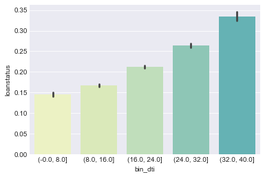

```python
sns.barplot(x='bin_dti', y= 'loanstatus', data = df_2014, palette=sns.color_palette("YlGnBu", 10))
```

The figure above shows that the debt-to-income ratio is very related with the loan status. Higher dti leads to higher chance of default.

### grade and subgrade

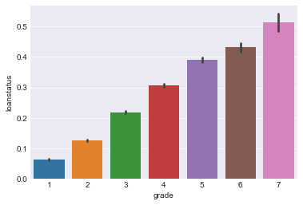

```python
sns.barplot(x = 'grade', y = 'loanstatus', data = df_2014)
```

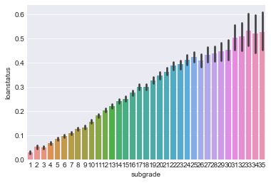

```python
sns.barplot(x = 'subgrade', y = 'loanstatus', data = df_2014)
```

Grade and subgrade clearly show an increasing trend with default rate. They are good indicators of risk levels.

### annualinc - Annual Income

The distribution of annual income is very skewed based on the violin plot, so the upper range of annual income is cut from 200000, with bin size of 25000.

```python
df_2014['bin_annualinc'] = pd.cut(df_2014.annualinc, bins=[0, 25000, 50000, 75000, \
                                                           100000, 125000, 150000, \
                                                           175000, 200000, max(df_2014.annualinc)], precision=0)
```

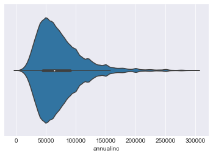

```python
sns.violinplot(x='annualinc', data= df_2014[df_2014['annualinc'] <300000])
```

```
[Text(0,0,'<25k'),
 Text(0,0,'25-50k'),
 Text(0,0,'50-75k'),
 Text(0,0,'75-100k'),
 Text(0,0,'100-125k'),
 Text(0,0,'125-150k'),
 Text(0,0,'150-175k'),
 Text(0,0,'175-200k'),
 Text(0,0,'>200k')]
```

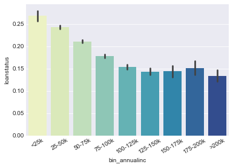

```python
fig = sns.barplot(x='bin_annualinc', y= 'loanstatus', data = df_2014, palette=sns.color_palette("YlGnBu", 10))
fig.set_xticklabels(labels=['<25k', '25-50k', '50-75k', '75-100k', '100-125k', '125-150k',\
                            '150-175k', '175-200k', '>200k'], rotation = 30)
```

The fitures show that the higher annual income, the lower chance of default.

### Intrate - Interest Rate

```python
df_2014['bin_intrate'] = pd.cut(df_2014.intrate, bins=5, precision=2)
```

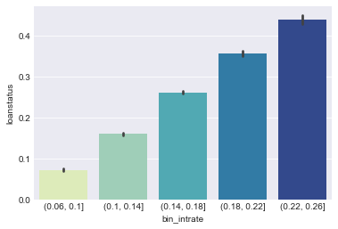

```python
fig = sns.barplot(x='bin_intrate', y= 'loanstatus', data = df_2014, palette=sns.color_palette("YlGnBu", 5))
```

The Interest Rate clearly shows a positive linear relationship with default rate.

### Installment

```python
df_2014['bin_installment'] = pd.cut(df_2014.installment, bins=5, precision=2)
```

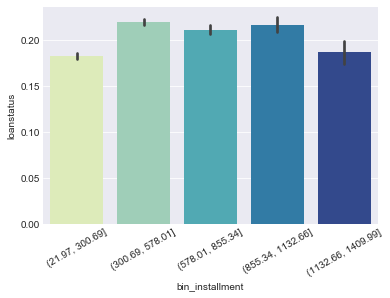

```python
fig = sns.barplot(x='bin_installment', y= 'loanstatus', data = df_2014, palette=sns.color_palette("YlGnBu", 5))
plt.xticks(rotation = 30)
```

The installment amount may have a parabolic relationship with the default rate.

### bcutil - Ration of total current loan balance to bank card credit limit (Portion of Balance)

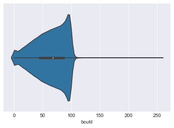

```python
sns.violinplot(x='bcutil', data= df_2014)
```

```python
df_2014['bin_bcutil'] = pd.cut(df_2014.bcutil, bins=[0, 20, 40, 60, \
                                                           80, 100, 120, \
                                                           max(df_2014.bcutil)], precision=0)
```

```
[Text(0,0,'<20%'),
 Text(0,0,'20-40%'),
 Text(0,0,'40-60%'),
 Text(0,0,'60-80%'),
 Text(0,0,'80-100%'),
 Text(0,0,'100-120%'),
 Text(0,0,'>120%')]
```

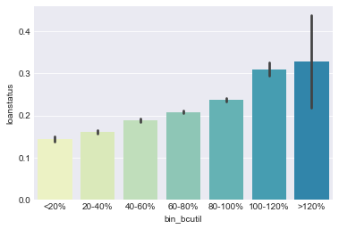

```python
fig = sns.barplot(x='bin_bcutil', y= 'loanstatus', data = df_2014, palette=sns.color_palette("YlGnBu", 10))
fig.set_xticklabels(labels=['<20%', '20-40%', '40-60%', '60-80%', '80-100%', '100-120%', '>120%'])
```

It is not surprising to see an increasing trend of default rate vs. Portion of Balance. The variance of default rate also increase with higher Portion of Balance.

### Credit History

```python
df_2014['bin_credit_hist'] = pd.cut(df_2014.credit_hist, bins=5, precision=0)
```

```python
df_2014.bin_credit_hist.value_counts()
```

```
(2228.0, 7208.0]      97456
(7208.0, 12163.0]     62096
(12163.0, 17119.0]     9150
(17119.0, 22074.0]      759
(22074.0, 27029.0]       14
Name: bin_credit_hist, dtype: int64
```

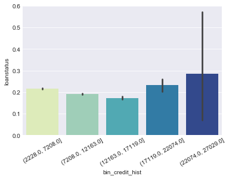

```python
fig = sns.barplot(x='bin_credit_hist', y= 'loanstatus', data = df_2014, palette=sns.color_palette("YlGnBu", 5))
plt.xticks(rotation = 30)
```

No apparent trend is seen between credit history and default rate, although the variation seems to increase with longer credit history.

# XGBoost Model Building

[go back to the top]

## Train/Test Splitting

Because this model uses historic data to predict future performances, when spliting the train/test datasets, the historic 2014 loan data are splitted into two parts chronologically: Dec/Nov/Oct data as the test set, and Jan - Sep as the train set.

```python
num_vars.remove('id')
```

```python
train_vars = num_vars + OHE_vars
```

```python
df_train = df_2014[train_vars + ['loanstatus']][df_2014.issued < dt.date(2014, 10, 1)]
df_test = df_2014[train_vars + ['loanstatus']][df_2014.issued >= dt.date(2014, 10, 1)]
```

```python
df_train.shape
```

```
(127364, 90)
```

```python
df_test.shape
```

```
(42111, 90)
```

## Parameter Auto-tuning

In this section both packages of XGBoost and BayesianOptimization are used. XGBoost is the model buiding algorithm. There are a number of parameters used in XGBoost, of which 5 parameters are of greater importance and given fine tuning. The parameter tuning is conducted with the Bayesian Optimization algorithm.

Bayesian Optmization is a constrained global optimization package built upon bayesian inference and gaussian process. It attempts to find the maximum value of an unknown function based on a few starting points, in as few iterations as possible. This technique is particularly suited for optimization of high cost functions. In this case the target function is the cross-validation score from XGBoost models. The function is defined as "xgb_evaluate", where the output of this function is the best cross-validation score for each set of parameters. The cross-validation uses "auc" (area under the ROC curve) as the scoring mectrics. The early stop callback is set at 50, meaning that if no improvement of score after 50 interations, the procedure is stopped.

The Bayesian Optimization process then maximizes the target function based on 8 initial points and interate 40 times to yield the best set of parameters leading to the highst "auc" scores.

```python
import xgboost as xgb
from bayes_opt import BayesianOptimization
from sklearn import metrics, preprocessing, cross_validation
```

```python
x_train = df_train[train_vars]
y_train = df_train['loanstatus']
x_test = df_test[train_vars]
y_test = df_test['loanstatus']
```

```python
dtrain = xgb.DMatrix(x_train, y_train, missing= np.nan)
dtest = xgb.DMatrix(x_test, missing= np.nan)
```

```python
def xgb_evaluate(min_child_weight,
                 colsample_bytree,
                 max_depth,
                 subsample,
                 gamma):
    params = dict()
    params['objective'] = 'binary:logistic'
    params['eta'] = 0.1
    params['max_depth'] = int(max_depth)
    params['min_child_weight'] = int(min_child_weight)
    params['colsample_bytree'] = colsample_bytree
    params['subsample'] = subsample
    params['gamma'] = gamma
    params['verbose_eval'] = True


    cv_result = xgb.cv(params, dtrain,
                       num_boost_round=15000,
                       nfold=5,
                       metrics={'auc'},
                       seed=1234,
                       stratified=True,
                       callbacks=[xgb.callback.early_stop(50)])

    return cv_result['test-auc-mean'].max()
```

```python
xgb_BO = BayesianOptimization(xgb_evaluate,
                             {'max_depth': (3, 10),
                              'min_child_weight': (0, 100),
                              'colsample_bytree': (0.5, 1),
                              'subsample': (0.5, 1),
                              'gamma': (0, 2)
                             }
                            )
```

```python
%%time
xgb_BO.maximize(init_points=8, n_iter=40)
```

```
Initialization
---------------------------------------------------------------------------------------------------------------
 Step |   Time |      Value |   colsample_bytree |     gamma |   max_depth |   min_child_weight |   subsample |
Multiple eval metrics have been passed: 'test-auc' will be used for early stopping.

Will train until test-auc hasn't improved in 50 rounds.
Stopping. Best iteration:

    1 | 05m12s |    0.72883 |             0.7858 |    1.3136 |      9.8255 |            74.5920 |      0.6287 |
Multiple eval metrics have been passed: 'test-auc' will be used for early stopping.

Will train until test-auc hasn't improved in 50 rounds.
Stopping. Best iteration:

    2 | 03m32s |    0.73013 |             0.5611 |    0.3318 |      6.8941 |            67.6846 |      0.5440 |
Multiple eval metrics have been passed: 'test-auc' will be used for early stopping.

Will train until test-auc hasn't improved in 50 rounds.
Stopping. Best iteration:

    3 | 05m46s |    0.73064 |             0.5916 |    1.8618 |      5.1459 |            80.7077 |      0.7117 |
Multiple eval metrics have been passed: 'test-auc' will be used for early stopping.

Will train until test-auc hasn't improved in 50 rounds.
Stopping. Best iteration:

    4 | 06m03s |    0.73098 |             0.7135 |    1.7018 |      4.3086 |            15.5271 |      0.6822 |
Multiple eval metrics have been passed: 'test-auc' will be used for early stopping.

Will train until test-auc hasn't improved in 50 rounds.
Stopping. Best iteration:

    5 | 03m58s |    0.72711 |             0.5695 |    0.3479 |      9.5931 |            43.2013 |      0.6223 |
Multiple eval metrics have been passed: 'test-auc' will be used for early stopping.

Will train until test-auc hasn't improved in 50 rounds.
Stopping. Best iteration:

    6 | 09m54s |    0.73192 |             0.9171 |    1.5230 |      3.2222 |            20.6057 |      0.8540 |
Multiple eval metrics have been passed: 'test-auc' will be used for early stopping.

Will train until test-auc hasn't improved in 50 rounds.
Stopping. Best iteration:

    7 | 04m50s |    0.72947 |             0.7991 |    1.5887 |      6.8414 |            23.6638 |      0.7984 |
Multiple eval metrics have been passed: 'test-auc' will be used for early stopping.

Will train until test-auc hasn't improved in 50 rounds.
Stopping. Best iteration:

    8 | 06m33s |    0.72854 |             0.9804 |
```

```
   1.2263 |      8.5930 |            60.2247 |      0.7299 |
Bayesian Optimization
---------------------------------------------------------------------------------------------------------------
 Step |   Time |      Value |   colsample_bytree |     gamma |   max_depth |   min_child_weight |   subsample |
Multiple eval metrics have been passed: 'test-auc' will be used for early stopping.

Will train until test-auc hasn't improved in 50 rounds.
Stopping. Best iteration:

    9 | 10m01s |    0.73204 |             0.9978 |
```

```
   0.2559 |      3.5493 |            99.9485 |      0.7863 |
Multiple eval metrics have been passed: 'test-auc' will be used for early stopping.

Will train until test-auc hasn't improved in 50 rounds.
Stopping. Best iteration:

   10 | 09m12s |    0.72970 |             0.9813 |    0.0049 |      4.8693 |             0.2297 |      0.9932 |
```

```
Multiple eval metrics have been passed: 'test-auc' will be used for early stopping.

Will train until test-auc hasn't improved in 50 rounds.
Stopping. Best iteration:

   11 | 09m14s |    0.73171 |             0.9831 |    0.0452 |      3.2714 |            86.7043 |      0.5200 |
Multiple eval metrics have been passed: 'test-auc' will be used for early stopping.

Will train until test-auc hasn't improved in 50 rounds.
Stopping. Best iteration:

   12 | 08m21s |    0.73204 |             0.5431 |    0.1201 |      3.1949 |            82.3529 |      0.9906 |
```

```
Multiple eval metrics have been passed: 'test-auc' will be used for early stopping.

Will train until test-auc hasn't improved in 50 rounds.
Stopping. Best iteration:

   13 | 09m01s |    0.73160 |             0.7980 |    0.0785 |      3.0846 |            16.8290 |      0.9043 |
```

```
Multiple eval metrics have been passed: 'test-auc' will be used for early stopping.

Will train until test-auc hasn't improved in 50 rounds.
Stopping. Best iteration:

   14 | 06m03s |    0.72990 |             0.5138 |    0.0795 |      8.3378 |            99.6047 |      0.9672 |
```

```
Multiple eval metrics have been passed: 'test-auc' will be used for early stopping.

Will train until test-auc hasn't improved in 50 rounds.
Stopping. Best iteration:

   15 | 06m41s |    0.73146 |             0.5102 |    0.0199 |      3.0055 |            97.2342 |      0.6625 |
Multiple eval metrics have been passed: 'test-auc' will be used for early stopping.

Will train until test-auc hasn't improved in 50 rounds.
Stopping. Best iteration:

   16 | 12m07s |    0.73222 |             0.9788 |    0.2154 |      3.0796 |            71.2835 |      0.9668 |
```

```
Multiple eval metrics have been passed: 'test-auc' will be used for early stopping.

Will train until test-auc hasn't improved in 50 rounds.
Stopping. Best iteration:

   17 | 06m20s |    0.73103 |             0.6036 |    1.9156 |      3.0251 |             0.6868 |      0.9258 |
Multiple eval metrics have been passed: 'test-auc' will be used for early stopping.

Will train until test-auc hasn't improved in 50 rounds.
Stopping. Best iteration:

   18 | 06m34s |    0.73152 |             0.5696 |    0.8966 |      3.0008 |            33.0816 |      0.5580 |
Multiple eval metrics have been passed: 'test-auc' will be used for early stopping.

Will train until test-auc hasn't improved in 50 rounds.
Stopping. Best iteration:

   19 | 13m14s |    0.73213 |             0.9110 |    0.2467 |      3.5537 |            77.3981 |      0.9706 |
Multiple eval metrics have been passed: 'test-auc' will be used for early stopping.

Will train until test-auc hasn't improved in 50 rounds.
Stopping. Best iteration:

   20 | 09m46s |    0.73186 |             0.9104 |    0.3241 |      3.3780 |            78.8026 |      0.8361 |
```

```
Multiple eval metrics have been passed: 'test-auc' will be used for early stopping.

Will train until test-auc hasn't improved in 50 rounds.
Stopping. Best iteration:

   21 | 08m24s |    0.73182 |             0.8794 |    1.8964 |      3.2264 |            93.1923 |      0.9890 |
```

```
Multiple eval metrics have been passed: 'test-auc' will be used for early stopping.

Will train until test-auc hasn't improved in 50 rounds.
Stopping. Best iteration:

   22 | 10m51s |    0.73147 |             0.8673 |    0.1433 |      3.1972 |            45.8883 |      0.9924 |
```

```
Multiple eval metrics have been passed: 'test-auc' will be used for early stopping.

Will train until test-auc hasn't improved in 50 rounds.
Stopping. Best iteration:

   23 | 08m03s |    0.73146 |             0.6521 |    1.7805 |      3.1887 |            33.0244 |      0.9947 |
```

```
Multiple eval metrics have been passed: 'test-auc' will be used for early stopping.

Will train until test-auc hasn't improved in 50 rounds.
Stopping. Best iteration:

   24 | 09m51s |    0.73201 |             0.9797 |    0.0000 |      3.4534 |            95.5402 |      1.0000 |
```

```
Multiple eval metrics have been passed: 'test-auc' will be used for early stopping.

Will train until test-auc hasn't improved in 50 rounds.
Stopping. Best iteration:

   25 | 12m09s |    0.73160 |             0.9285 |    0.0447 |      3.1035 |            27.7662 |      0.8856 |
```

```
Multiple eval metrics have been passed: 'test-auc' will be used for early stopping.

Will train until test-auc hasn't improved in 50 rounds.
Stopping. Best iteration:

   26 | 09m51s |    0.73199 |             0.6862 |    0.0604 |      3.1593 |            73.6900 |      0.9239 |
```

```
Multiple eval metrics have been passed: 'test-auc' will be used for early stopping.

Will train until test-auc hasn't improved in 50 rounds.
Stopping. Best iteration:

   27 | 05m30s |    0.73056 |             0.5696 |    0.1263 |      3.0003 |             0.3136 |      0.5102 |
```

```
Multiple eval metrics have been passed: 'test-auc' will be used for early stopping.

Will train until test-auc hasn't improved in 50 rounds.
Stopping. Best iteration:

   28 | 09m52s |    0.73199 |             0.7863 |    0.1254 |      3.0996 |            84.7682 |      0.9475 |
```

```
Multiple eval metrics have been passed: 'test-auc' will be used for early stopping.

Will train until test-auc hasn't improved in 50 rounds.
Stopping. Best iteration:

   29 | 12m41s |    0.73239 |             0.9668 |    0.0804 |      3.7150 |            60.8399 |      0.9358 |
```

```
Multiple eval metrics have been passed: 'test-auc' will be used for early stopping.

Will train until test-auc hasn't improved in 50 rounds.
Stopping. Best iteration:

   30 | 06m50s |    0.72986 |             0.7011 |    0.0773 |      7.0201 |            82.1718 |      0.9744 |
```

```
Multiple eval metrics have been passed: 'test-auc' will be used for early stopping.

Will train until test-auc hasn't improved in 50 rounds.
Stopping. Best iteration:

   31 | 04m08s |    0.72444 |             0.5077 |    1.9193 |      9.7440 |             0.2684 |      0.9959 |
Multiple eval metrics have been passed: 'test-auc' will be used for early stopping.

Will train until test-auc hasn't improved in 50 rounds.
Stopping. Best iteration:

   32 | 08m24s |    0.73146 |             0.9640 |    1.0545 |      3.0378 |             6.7360 |      0.6267 |
```

```
Multiple eval metrics have been passed: 'test-auc' will be used for early stopping.

Will train until test-auc hasn't improved in 50 rounds.
Stopping. Best iteration:

   33 | 06m52s |    0.73189 |             0.5266 |    1.8507 |      3.1247 |            62.6717 |      0.9930 |
```

```
Multiple eval metrics have been passed: 'test-auc' will be used for early stopping.

Will train until test-auc hasn't improved in 50 rounds.
Stopping. Best iteration:

   34 | 08m03s |    0.73007 |             0.9792 |    1.9814 |      5.5677 |            99.5109 |      0.6055 |
```

```
Multiple eval metrics have been passed: 'test-auc' will be used for early stopping.

Will train until test-auc hasn't improved in 50 rounds.
Stopping. Best iteration:

   35 | 10m42s |    0.73207 |             0.8776 |    0.1947 |      3.0370 |            37.4982 |      0.8586 |
```

```
Multiple eval metrics have been passed: 'test-auc' will be used for early stopping.

Will train until test-auc hasn't improved in 50 rounds.
Stopping. Best iteration:

   36 | 08m02s |    0.73040 |             0.9435 |    1.9364 |      3.6933 |             0.0353 |      0.5775 |
```

```
Multiple eval metrics have been passed: 'test-auc' will be used for early stopping.

Will train until test-auc hasn't improved in 50 rounds.
Stopping. Best iteration:

   37 | 07m37s |    0.73228 |             0.5012 |    0.0496 |      3.2539 |            65.9431 |      0.9829 |
```

```
Multiple eval metrics have been passed: 'test-auc' will be used for early stopping.

Will train until test-auc hasn't improved in 50 rounds.
Stopping. Best iteration:

   38 | 10m57s |    0.73195 |             0.8048 |    0.0392 |      3.3632 |            89.0584 |      0.9943 |
```

```
Multiple eval metrics have been passed: 'test-auc' will be used for early stopping.

Will train until test-auc hasn't improved in 50 rounds.
Stopping. Best iteration:

   39 | 10m46s |    0.73213 |             0.9985 |    0.4488 |      3.2895 |            62.7708 |      0.8729 |
```

```
Multiple eval metrics have been passed: 'test-auc' will be used for early stopping.

Will train until test-auc hasn't improved in 50 rounds.
Stopping. Best iteration:

   40 | 09m11s |    0.73207 |             0.8781 |    0.0416 |      3.0927 |            55.8416 |      0.8445 |
```

```
Multiple eval metrics have been passed: 'test-auc' will be used for early stopping.

Will train until test-auc hasn't improved in 50 rounds.
Stopping. Best iteration:

   41 | 09m49s |    0.73186 |             0.6725 |    0.1274 |      3.2319 |            60.6612 |      0.9870 |
```

```
Multiple eval metrics have been passed: 'test-auc' will be used for early stopping.

Will train until test-auc hasn't improved in 50 rounds.
Stopping. Best iteration:

   42 | 09m29s |    0.73008 |             0.9935 |    1.9106 |      5.3480 |            50.0230 |      0.9723 |
Multiple eval metrics have been passed: 'test-auc' will be used for early stopping.

Will train until test-auc hasn't improved in 50 rounds.
Stopping. Best iteration:

   43 | 08m09s |    0.72918 |             0.9969 |    0.0409 |      6.6822 |            33.3649 |      0.9417 |
```

```
Multiple eval metrics have been passed: 'test-auc' will be used for early stopping.

Will train until test-auc hasn't improved in 50 rounds.
Stopping. Best iteration:

   44 | 06m34s |    0.72496 |             0.9035 |    0.0871 |      9.9590 |            13.1619 |      0.7603 |
```

```
Multiple eval metrics have been passed: 'test-auc' will be used for early stopping.

Will train until test-auc hasn't improved in 50 rounds.
Stopping. Best iteration:

   45 | 08m20s |    0.73113 |             0.9497 |    1.9554 |      4.6478 |            67.2059 |      0.9848 |
```

```
Multiple eval metrics have been passed: 'test-auc' will be used for early stopping.

Will train until test-auc hasn't improved in 50 rounds.
Stopping. Best iteration:

   46 | 10m16s |    0.73227 |             0.9970 |    1.9748 |      3.0046 |            40.3501 |      0.7354 |
Multiple eval metrics have been passed: 'test-auc' will be used for early stopping.

Will train until test-auc hasn't improved in 50 rounds.
Stopping. Best iteration:

   47 | 08m25s |    0.72966 |             0.9778 |    0.0352 |      6.7052 |            55.3277 |      0.9521 |
```

```
Multiple eval metrics have been passed: 'test-auc' will be used for early stopping.

Will train until test-auc hasn't improved in 50 rounds.
Stopping. Best iteration:

   48 | 10m30s |    0.73211 |             0.9932 |    1.9361 |      3.1202 |            55.9112 |      0.8580 |
```

```
CPU times: user 23h 50min 24s, sys: 14min 39s, total: 1d 5min 4s
Wall time: 6h 43min 28s
```

```python
BO_scores = pd.DataFrame(xgb_BO.res['all']['params'])
BO_scores['score'] = pd.DataFrame(xgb_BO.res['all']['values'])
BO_scores = BO_scores.sort_values(by='score',ascending=False).reset_index()
BO_scores.head()
```

|  | index | colsample_bytree | gamma | max_depth | min_child_weight | subsample | score |
| --- | --- | --- | --- | --- | --- | --- | --- |
| 0 | 20 | 0.966764 | 0.080371 | 3.714995 | 60.839938 | 0.935822 | 0.732392 |
| 1 | 28 | 0.501193 | 0.049590 | 3.253927 | 65.943135 | 0.982906 | 0.732281 |
| 2 | 37 | 0.997029 | 1.974814 | 3.004641 | 40.350106 | 0.735441 | 0.732275 |
| 3 | 7 | 0.978806 | 0.215396 | 3.079573 | 71.283494 | 0.966837 | 0.732224 |
| 4 | 10 | 0.911004 | 0.246685 | 3.553736 | 77.398079 | 0.970618 | 0.732133 |

## Find Best Parameters

```python
best_params = dict()

best_params['max_depth'] = int(BO_scores['max_depth'][0])
best_params['min_child_weight'] = int(BO_scores['min_child_weight'][0])
best_params['colsample_bytree'] = BO_scores['colsample_bytree'][0]
best_params['subsample'] = BO_scores['subsample'][0]
best_params['gamma'] = BO_scores['gamma'][0]

best_params['objective'] = 'binary:logistic'
best_params['eta'] = 0.02
best_params['seed'] = 1234
```

```python
best_params
```

```
{'colsample_bytree': 0.96676375041398677,
 'eta': 0.02,
 'gamma': 0.080370624378502509,
 'max_depth': 3,
 'min_child_weight': 60,
 'objective': 'binary:logistic',
 'seed': 1234,
 'subsample': 0.93582224874989284}
```

```python
cv_result = xgb.cv(best_params, dtrain,
                   num_boost_round=15000,
                   nfold=5,
                   metrics={'auc'},
                   seed=1234,
                   stratified=True,
                   callbacks=[xgb.callback.early_stop(200)],
                   verbose_eval=50)


best_iteration = len(cv_result)
best_score = cv_result['test-auc-mean'].max()
print("Best score %f, best iteration %d" % (best_score,best_iteration) )
```

```
Multiple eval metrics have been passed: 'test-auc' will be used for early stopping.

Will train until test-auc hasn't improved in 200 rounds.
Stopping. Best iteration:

Best score 0.732764, best iteration 2489
```

```python
xgb_final = xgb.train(best_params, dtrain, num_boost_round=best_iteration)
```

# Model Integration

[go back to the top]

## Pickle Model (xgb_bo) and Feature.

```python
import pickle
```

```python
with open('model.pkl', 'wb') as outfile:
    pickle.dump(xgb_final, outfile)
```

# Model Evaluation

[go back to the top]

## Feature Importance

The importance of features is generated based on the feature importance scores from the XGBoost model. From the table and plot below it is found that the top 10 important features include Annual Income, Debt to Income Ratio, Interest Rate, Portion of Balance, and so on. Generally the important features match the trend observed in the Feature Responses Visualization.

```python
importance = xgb_final.get_fscore()
df_importance = pd.DataFrame(list(importance.items()), columns = ['feature', 'fscore'])
df_importance['fscore'] = df_importance['fscore']/df_importance['fscore'].sum()
df_importance.sort_values(['fscore'], ascending= False, inplace= True)
```

```python
df_importance.head(10)
```

|  | feature | fscore |
| --- | --- | --- |
| 6 | annualinc | 0.046991 |
| 3 | dti | 0.043863 |
| 1 | intrate | 0.038671 |
| 20 | addrzip | 0.037473 |
| 7 | loanamount | 0.032548 |
| 12 | installment | 0.027290 |
| 15 | mosinoldrevtlop | 0.027023 |
| 4 | avgcurbal | 0.026824 |
| 25 | revolbal | 0.025759 |
| 37 | bcutil | 0.023363 |

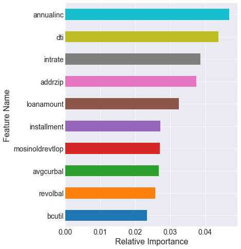

```python
df_importance[:10].sort_values(by='fscore').plot(kind = 'barh', x = 'feature', y = 'fscore', legend= False, figsize=(6,8) )
plt.xlabel('Relative Importance', fontsize = 16)
plt.ylabel('Feature Name', fontsize = 16)
plt.tick_params(labelsize = 14)
```